# ANALYZE WERATEGODS TWITTER DATA

|  | tweet_id | in_reply_to_status_id | in_reply_to_user_id | timestamp | source | text | retweeted_status_id | retweeted_status_user_id | retweeted_status_timestamp | expanded_urls | rating_numerator | rating_denominator | name | doggo | floofer | pupper | puppo |
| --- | --- | --- | --- | --- | --- | --- | --- | --- | --- | --- | --- | --- | --- | --- | --- | --- | --- |
| 262 | 842765311967449089 | NaN | NaN | 2017-03-17 15:51:22 +0000 | <a href="http://twitter.com/download/iphone" rel="nofollow">Twitter for iPhone</a> | Meet Indie. She's not a fan of baths but she's definitely a fan of hide &amp; seek. 12/10 click the link to help Indie\n\nhttps://t.co/fvGkIuAlFK https://t.co/kiCFtmJd7l | NaN | NaN | NaN | https://www.gofundme.com/get-indie-home/,https://twitter.com/dog_rates/status/842765311967449089/photo/1,https://twitter.com/dog_rates/status/842765311967449089/photo/1 | 12 | 10 | Indie | None | None | None | None |
| 273 | 840728873075638272 | NaN | NaN | 2017-03-12 00:59:17 +0000 | <a href="http://twitter.com/download/iphone" rel="nofollow">Twitter for iPhone</a> | RT @dog_rates: This is Pipsy. He is a fluffball. Enjoys traveling the sea &amp; getting tangled in leash. 12/10 I would kill for Pipsy https://… | 6.671522e+17 | 4.196984e+09 | 2015-11-19 01:27:25 +0000 | https://twitter.com/dog_rates/status/667152164079423490/photo/1 | 12 | 10 | Pipsy | None | None | None | None |
| 320 | 834458053273591808 | NaN | NaN | 2017-02-22 17:41:18 +0000 | <a href="http://twitter.com/download/iphone" rel="nofollow">Twitter for iPhone</a> | Meet Chester (bottom) &amp; Harold (top). They are different dogs not only in appearance, but in personality as well. Both 12/10 symbiotic af https://t.co/8ZOZS2FSJe | NaN | NaN | NaN | https://twitter.com/dog_rates/status/834458053273591808/photo/1 | 12 | 10 | Chester | None | None | None | None |
| 461 | 817536400337801217 | NaN | NaN | 2017-01-07 01:00:41 +0000 | <a href="http://twitter.com/download/iphone" rel="nofollow">Twitter for iPhone</a> | Say hello to Eugene &amp; Patti Melt. No matter how dysfunctional they get, they will never top their owners. Both 12/10 would pet at same time https://t.co/jQUdvtdYMu | NaN | NaN | NaN | https://twitter.com/dog_rates/status/817536400337801217/photo/1,https://twitter.com/dog_rates/status/817536400337801217/photo/1,https://twitter.com/dog_rates/status/817536400337801217/photo/1,https://… | 12 | 10 | Eugene | None | None | None | None |
| 485 | 814578408554463233 | NaN | NaN | 2016-12-29 21:06:41 +0000 | <a href="http://twitter.com/download/iphone" rel="nofollow">Twitter for iPhone</a> | RT @dog_rates: Meet Beau &amp; Wilbur. Wilbur stole Beau's bed from him. Wilbur now has so much room for activities. 9/10 for both pups https:/… | 6.981954e+17 | 4.196984e+09 | 2016-02-12 17:22:12 +0000 | https://twitter.com/dog_rates/status/698195409219559425/photo/1 | 9 | 10 | Beau | None | None | None | None |
| 516 | 810984652412424192 | NaN | NaN | 2016-12-19 23:06:23 +0000 | <a href="http://twitter.com/download/iphone" rel="nofollow">Twitter for iPhone</a> | Meet Sam. She smiles 24/7 &amp; secretly aspires to be a reindeer. \nKeep Sam smiling by clicking and sharing this link:\nhttps://t.co/98tB8y7y7t https://t.co/LouL5vdvxx | NaN | NaN | NaN | https://www.gofundme.com/sams-smile,https://twitter.com/dog_rates/status/810984652412424192/photo/1 | 24 | 7 | Sam | None | None | None | None |
| 799 | 772826264096874500 | NaN | NaN | 2016-09-05 15:58:34 +0000 | <a href="http://twitter.com/download/iphone" rel="nofollow">Twitter for iPhone</a> | Meet Roosevelt. He's preparing for takeoff. Make sure tray tables are in their full pupright &amp; licked position\n11/10 https://t.co/7CQkn3gHOQ | NaN | NaN | NaN | https://twitter.com/dog_rates/status/772826264096874500/photo/1 | 11 | 10 | Roosevelt | None | None | None | None |
| 889 | 759793422261743616 | NaN | NaN | 2016-07-31 16:50:42 +0000 | <a href="http://twitter.com/download/iphone" rel="nofollow">Twitter for iPhone</a> | Meet Maggie &amp; Lila. Maggie is the doggo, Lila is the pupper. They are sisters. Both 12/10 would pet at the same time https://t.co/MYwR4DQKll | NaN | NaN | NaN | https://twitter.com/dog_rates/status/759793422261743616/photo/1,https://twitter.com/dog_rates/status/759793422261743616/photo/1 | 12 | 10 | Maggie | doggo | None | pupper | None |
| 898 | 758854675097526272 | NaN | NaN | 2016-07-29 02:40:28 +0000 | <a href="http://twitter.com/download/iphone" rel="nofollow">Twitter for iPhone</a> | This is Lilli Bee &amp; Honey Bear. Unfortunately, they were both born with no eyes. So heckin sad. Both 11/10 https://t.co/4UrfOZhztW | NaN | NaN | NaN | https://twitter.com/dog_rates/status/758854675097526272/photo/1,https://twitter.com/dog_rates/status/758854675097526272/photo/1,https://twitter.com/dog_rates/status/758854675097526272/photo/1,https://… | 11 | 10 | Lilli | None | None | None | None |
| 976 | 750026558547456000 | NaN | NaN | 2016-07-04 18:00:41 +0000 | <a href="https://about.twitter.com/products/tweetdeck" rel="nofollow">TweetDeck</a> | Meet Jax &amp; Jil. Jil is yelling the pledge of allegiance. If u cant take the freedom get out the kitchen Jax. 10/10s https://t.co/jrg29NDNhI | NaN | NaN | NaN | https://twitter.com/dog_rates/status/750026558547456000/photo/1 | 10 | 10 | Jax | None | None | None | None |
| 1104 | 735137028879360001 | NaN | NaN | 2016-05-24 15:55:00 +0000 | <a href="http://twitter.com/download/iphone" rel="nofollow">Twitter for iPhone</a> | Meet Buckley. His family &amp; some neighbors came over to watch him perform but he's nervous af. 9/10 u got this pupper https://t.co/5bdCpPlno9 | NaN | NaN | NaN | https://twitter.com/dog_rates/status/735137028879360001/photo/1 | 9 | 10 | Buckley | None | None | pupper | None |
| 1179 | 719367763014393856 | NaN | NaN | 2016-04-11 03:33:34 +0000 | <a href="http://twitter.com/download/iphone" rel="nofollow">Twitter for iPhone</a> | Meet Sid &amp; Murphy. Murphy floats alongside Sid and whispers motivational quotes in his ear. Magical af. Both 11/10 https://t.co/7mmjyearQW | NaN | NaN | NaN | https://twitter.com/dog_rates/status/719367763014393856/photo/1 | 11 | 10 | Sid | None | None | None | None |
| 1199 | 716791146589110272 | NaN | NaN | 2016-04-04 00:55:01 +0000 | <a href="http://twitter.com/download/iphone" rel="nofollow">Twitter for iPhone</a> | Meet Jennifur. She's supposed to be navigating. Not even buckled up. Insubordinate &amp; churlish. 11/10 would still pet https://t.co/h0trcJohYO | NaN | NaN | NaN | https://twitter.com/dog_rates/status/716791146589110272/photo/1 | 11 | 10 | Jennifur | None | None | None | None |
| 1222 | 714258258790387713 | NaN | NaN | 2016-03-28 01:10:13 +0000 | <a href="http://twitter.com/download/iphone" rel="nofollow">Twitter for iPhone</a> | Meet Travis and Flurp. Travis is pretty chill but Flurp can't lie down properly. 10/10 &amp; 8/10\nget it together Flurp https://t.co/Akzl5ynMmE | NaN | NaN | NaN | https://twitter.com/dog_rates/status/714258258790387713/photo/1 | 10 | 10 | Travis | None | None | None | None |
| 1274 | 709198395643068416 | NaN | NaN | 2016-03-14 02:04:08 +0000 | <a href="http://twitter.com/download/iphone" rel="nofollow">Twitter for iPhone</a> | From left to right:\nCletus, Jerome, Alejandro, Burp, &amp; Titson\nNone know where camera is. 45/50 would hug all at once https://t.co/sedre1ivTK | NaN | NaN | NaN | https://twitter.com/dog_rates/status/709198395643068416/photo/1 | 45 | 50 | None | None | None | None | None |
| 1366 | 702671118226825216 | NaN | NaN | 2016-02-25 01:47:04 +0000 | <a href="http://twitter.com/download/iphone" rel="nofollow">Twitter for iPhone</a> | Meet Rambo &amp; Kiwi. Rambo's the pup with the sharp toes &amp; rad mohawk. One stays woke while one sleeps. 10/10 for both https://t.co/MpH1Fe9LhZ | NaN | NaN | NaN | https://twitter.com/dog_rates/status/702671118226825216/photo/1 | 10 | 10 | Rambo | None | None | None | None |
| 1421 | 698195409219559425 | NaN | NaN | 2016-02-12 17:22:12 +0000 | <a href="http://twitter.com/download/iphone" rel="nofollow">Twitter for iPhone</a> | Meet Beau &amp; Wilbur. Wilbur stole Beau's bed from him. Wilbur now has so much room for activities. 9/10 for both pups https://t.co/GPaoH5qWEk | NaN | NaN | NaN | https://twitter.com/dog_rates/status/698195409219559425/photo/1 | 9 | 10 | Beau | None | None | None | None |
| 1465 | 694352839993344000 | NaN | NaN | 2016-02-02 02:53:12 +0000 | <a href="http://twitter.com/download/iphone" rel="nofollow">Twitter for iPhone</a> | Meet Oliviér. He takes killer selfies. Has a dog of his own. It leaps at random &amp; can't bark for shit. 10/10 &amp; 5/10 https://t.co/6NgsQJuSBJ | NaN | NaN | NaN | https://twitter.com/dog_rates/status/694352839993344000/photo/1,https://twitter.com/dog_rates/status/694352839993344000/photo/1,https://twitter.com/dog_rates/status/694352839993344000/photo/1,https://… | 10 | 10 | Oliviér | None | None | None | None |
| 1481 | 693280720173801472 | NaN | NaN | 2016-01-30 03:52:58 +0000 | <a href="http://twitter.com/download/iphone" rel="nofollow">Twitter for iPhone</a> | This is Sadie and her 2 pups Shebang &amp; Ruffalo. Sadie says single parenting is challenging but rewarding. All 10/10 https://t.co/UzbhwXcLne | NaN | NaN | NaN | https://twitter.com/dog_rates/status/693280720173801472/photo/1 | 10 | 10 | Sadie | None | None | None | None |
| 1508 | 691483041324204033 | NaN | NaN | 2016-01-25 04:49:38 +0000 | <a href="http://twitter.com/download/iphone" rel="nofollow">Twitter for iPhone</a> | When bae says they can't go out but you see them with someone else that same night. 5/10 &amp; 10/10 for heartbroken pup https://t.co/aenk0KpoWM | NaN | NaN | NaN | https://twitter.com/dog_rates/status/691483041324204033/photo/1,https://twitter.com/dog_rates/status/691483041324204033/photo/1,https://twitter.com/dog_rates/status/691483041324204033/photo/1,https://… | 5 | 10 | None | None | None | None | None |
| 1524 | 690597161306841088 | NaN | NaN | 2016-01-22 18:09:28 +0000 | <a href="http://twitter.com/download/iphone" rel="nofollow">Twitter for iPhone</a> | This is Lolo. She's America af. Behind in science &amp; math but can say whatever she wants on Twitter. 11/10 ...Merica https://t.co/Nwi3SYe8KA | NaN | NaN | NaN | https://twitter.com/dog_rates/status/690597161306841088/photo/1 | 11 | 10 | Lolo | None | None | None | None |
| 1538 | 689835978131935233 | NaN | NaN | 2016-01-20 15:44:48 +0000 | <a href="http://twitter.com/download/iphone" rel="nofollow">Twitter for iPhone</a> | Meet Fynn &amp; Taco. Fynn is an all-powerful leaf lord and Taco is in the wrong place at the wrong time. 11/10 &amp; 10/10 https://t.co/MuqHPvtL8c | NaN | NaN | NaN | https://twitter.com/dog_rates/status/689835978131935233/photo/1 | 11 | 10 | Fynn | None | None | None | None |
| 1569 | 687807801670897665 | NaN | NaN | 2016-01-15 01:25:33 +0000 | <a href="http://twitter.com/download/iphone" rel="nofollow">Twitter for iPhone</a> | Meet Trooper &amp; Maya. Trooper protects Maya from bad things like dognappers and Comcast. So touching. 11/10 for both https://t.co/c98k1IoZKy | NaN | NaN | NaN | https://twitter.com/dog_rates/status/687807801670897665/photo/1 | 11 | 10 | Trooper | None | None | None | None |
| 1593 | 686386521809772549 | NaN | NaN | 2016-01-11 03:17:53 +0000 | <a href="http://twitter.com/download/iphone" rel="nofollow">Twitter for iPhone</a> | Say hello to Crimson. He's a Speckled Winnebago. Main passions are air hockey &amp; parkour. 11/10 would pet thoroughly https://t.co/J5aI7SjzDc | NaN | NaN | NaN | https://twitter.com/dog_rates/status/686386521809772549/photo/1 | 11 | 10 | Crimson | None | None | None | None |
| 1621 | 684926975086034944 | NaN | NaN | 2016-01-07 02:38:10 +0000 | <a href="http://twitter.com/download/iphone" rel="nofollow">Twitter for iPhone</a> | Meet Bruiser &amp; Charlie. They are the best of pals. Been through it all together. Both 11/10. 1 like=1 friendship https://t.co/PEXHuvSVD4 | NaN | NaN | NaN | https://twitter.com/dog_rates/status/684926975086034944/photo/1 | 11 | 10 | Bruiser | None | None | None | None |
| 1646 | 683834909291606017 | NaN | NaN | 2016-01-04 02:18:42 +0000 | <a href="http://twitter.com/download/iphone" rel="nofollow">Twitter for iPhone</a> | Here we see a faulty pupper. Might need to replace batteries. Try turning off &amp; back on again. 9/10 would still pet https://t.co/O1E4AtHVxO | NaN | NaN | NaN | https://twitter.com/dog_rates/status/683834909291606017/video/1 | 9 | 10 | None | None | None | pupper | None |
| 1707 | 680801747103793152 | NaN | NaN | 2015-12-26 17:25:59 +0000 | <a href="http://twitter.com/download/iphone" rel="nofollow">Twitter for iPhone</a> | Great picture here. Dog on the right panicked &amp; forgot about his tongue. Middle green dog must've fainted. All 10/10 https://t.co/31npKUAox0 | NaN | NaN | NaN | https://twitter.com/dog_rates/status/680801747103793152/photo/1 | 10 | 10 | None | None | None | None | None |
| 1763 | 678446151570427904 | NaN | NaN | 2015-12-20 05:25:42 +0000 | <a href="http://twitter.com/download/iphone" rel="nofollow">Twitter for iPhone</a> | Touching scene here. Really stirs up the emotions. The bond between father &amp; son. So beautiful. 10/10 for both pups https://t.co/AJWJHov5gx | NaN | NaN | NaN | https://twitter.com/dog_rates/status/678446151570427904/photo/1 | 10 | 10 | None | None | None | None | None |
| 1795 | 677314812125323265 | NaN | NaN | 2015-12-17 02:30:09 +0000 | <a href="http://twitter.com/download/iphone" rel="nofollow">Twitter for iPhone</a> | Meet Tassy &amp; Bee. Tassy is pretty chill, but Bee is convinced the Ruffles are haunted. 10/10 &amp; 11/10 respectively https://t.co/fgORpmTN9C | NaN | NaN | NaN | https://twitter.com/dog_rates/status/677314812125323265/photo/1,https://twitter.com/dog_rates/status/677314812125323265/photo/1 | 10 | 10 | Tassy | None | None | None | None |
| 1812 | 676811746707918848 | NaN | NaN | 2015-12-15 17:11:09 +0000 | <a href="http://twitter.com/download/iphone" rel="nofollow">Twitter for iPhone</a> | Say hello to Penny &amp; Gizmo. They are practicing their caroling. The ambition in the room is tangible. 9/10 for both https://t.co/aqBHjjh5VD | NaN | NaN | NaN | https://twitter.com/dog_rates/status/676811746707918848/photo/1 | 9 | 10 | Penny | None | None | None | None |
| 1817 | 676603393314578432 | NaN | NaN | 2015-12-15 03:23:14 +0000 | <a href="http://twitter.com/download/iphone" rel="nofollow">Twitter for iPhone</a> | This is Godzilla pupper. He had a ruff childhood &amp; now deflects that pain outward by terrorizing cities. Tragic 9/10 https://t.co/g1tLGkyaxr | NaN | NaN | NaN | https://twitter.com/dog_rates/status/676603393314578432/photo/1 | 9 | 10 | Godzilla | None | None | pupper | None |
| 1842 | 675870721063669760 | 6.757073e+17 | 4.196984e+09 | 2015-12-13 02:51:51 +0000 | <a href="http://twitter.com/download/iphone" rel="nofollow">Twitter for iPhone</a> | &amp; this is Yoshi. Another world record contender 11/10 (what the hell is happening why are there so many contenders?) https://t.co/QG708dDNH6 | NaN | NaN | NaN | https://twitter.com/dog_rates/status/675870721063669760/photo/1 | 11 | 10 | None | None | None | None | None |
| 1897 | 674737130913071104 | NaN | NaN | 2015-12-09 23:47:22 +0000 | <a href="http://twitter.com/download/iphone" rel="nofollow">Twitter for iPhone</a> | Meet Rufio. He is unaware of the pink legless pupper wrapped around him. Might want to get that checked 10/10 &amp; 4/10 https://t.co/KNfLnYPmYh | NaN | NaN | NaN | https://twitter.com/dog_rates/status/674737130913071104/photo/1 | 10 | 10 | Rufio | None | None | pupper | None |
| 1899 | 674670581682434048 | NaN | NaN | 2015-12-09 19:22:56 +0000 | <a href="http://twitter.com/download/iphone" rel="nofollow">Twitter for iPhone</a> | Meet Jeb &amp; Bush. Jeb is somehow stuck in that fence and Bush won't stop whispering sweet nothings in his ear. 9/10s https://t.co/NRNExUy9Hm | NaN | NaN | NaN | https://twitter.com/dog_rates/status/674670581682434048/photo/1 | 9 | 10 | Jeb | None | None | None | None |
| 1901 | 674646392044941312 | NaN | NaN | 2015-12-09 17:46:48 +0000 | <a href="http://twitter.com/download/iphone" rel="nofollow">Twitter for iPhone</a> | Two gorgeous dogs here. Little waddling dog is a rebel. Refuses to look at camera. Must be a preteen. 5/10 &amp; 8/10 https://t.co/YPfw7oahbD | NaN | NaN | NaN | https://twitter.com/dog_rates/status/674646392044941312/photo/1 | 5 | 10 | None | None | None | None | None |
| 1913 | 674372068062928900 | NaN | NaN | 2015-12-08 23:36:44 +0000 | <a href="http://twitter.com/download/iphone" rel="nofollow">Twitter for iPhone</a> | Meet Chesney. On the outside he stays calm &amp; collected. On the inside he's having a complete mental breakdown. 10/10 https://t.co/G4m0TFY9uc | NaN | NaN | NaN | https://twitter.com/dog_rates/status/674372068062928900/photo/1 | 10 | 10 | Chesney | None | None | None | None |
| 1931 | 674036086168010753 | NaN | NaN | 2015-12-08 01:21:40 +0000 | <a href="http://twitter.com/download/iphone" rel="nofollow">Twitter for iPhone</a> | Meet Daisy. She has no eyes &amp; her face has been blurry since birth. Quite the trooper tho. Still havin a blast. 9/10 https://t.co/jcNdw43BIP | NaN | NaN | NaN | https://twitter.com/dog_rates/status/674036086168010753/photo/1 | 9 | 10 | Daisy | None | None | None | None |
| 2031 | 671768281401958400 | NaN | NaN | 2015-12-01 19:10:13 +0000 | <a href="http://twitter.com/download/iphone" rel="nofollow">Twitter for iPhone</a> | When you try to recreate the scene from Lady &amp; The Tramp but then remember you don't have a significant other. 10/10 https://t.co/TASnD8Q08S | NaN | NaN | NaN | https://twitter.com/dog_rates/status/671768281401958400/photo/1,https://twitter.com/dog_rates/status/671768281401958400/photo/1 | 10 | 10 | None | None | None | None | None |
| 2037 | 671561002136281088 | NaN | NaN | 2015-12-01 05:26:34 +0000 | <a href="http://twitter.com/download/iphone" rel="nofollow">Twitter for iPhone</a> | This is the best thing I've ever seen so spread it like wildfire &amp; maybe we'll find the genius who created it. 13/10 https://t.co/q6RsuOVYwU | NaN | NaN | NaN | https://twitter.com/dog_rates/status/671561002136281088/photo/1 | 13 | 10 | the | None | None | None | None |
| 2064 | 671154572044468225 | NaN | NaN | 2015-11-30 02:31:34 +0000 | <a href="http://twitter.com/download/iphone" rel="nofollow">Twitter for iPhone</a> | Meet Holly. She's trying to teach small human-like pup about blocks but he's not paying attention smh. 11/10 &amp; 8/10 https://t.co/RcksaUrGNu | NaN | NaN | NaN | https://twitter.com/dog_rates/status/671154572044468225/photo/1 | 11 | 10 | Holly | None | None | None | None |
| 2084 | 670807719151067136 | NaN | NaN | 2015-11-29 03:33:17 +0000 | <a href="http://twitter.com/download/iphone" rel="nofollow">Twitter for iPhone</a> | Say hello to Andy. He can balance on one foot, obliterate u in checkers, &amp; transform into a rug. 11/10 much talents https://t.co/idzH8JH06g | NaN | NaN | NaN | https://twitter.com/dog_rates/status/670807719151067136/photo/1,https://twitter.com/dog_rates/status/670807719151067136/photo/1,https://twitter.com/dog_rates/status/670807719151067136/photo/1 | 11 | 10 | Andy | None | None | None | None |
| 2096 | 670755717859713024 | NaN | NaN | 2015-11-29 00:06:39 +0000 | <a href="http://twitter.com/download/iphone" rel="nofollow">Twitter for iPhone</a> | Say hello to Gin &amp; Tonic. They're having a staring contest. Very very intense. 9/10 for both https://t.co/F6bI9dF16E | NaN | NaN | NaN | https://twitter.com/dog_rates/status/670755717859713024/photo/1 | 9 | 10 | Gin | None | None | None | None |
| 2137 | 670046952931721218 | NaN | NaN | 2015-11-27 01:10:17 +0000 | <a href="http://twitter.com/download/iphone" rel="nofollow">Twitter for iPhone</a> | This is Ben &amp; Carson. It's impossible for them to tilt their heads in the same direction. Cheeky wink by Ben. 11/10s https://t.co/465sIBdvzU | NaN | NaN | NaN | https://twitter.com/dog_rates/status/670046952931721218/photo/1 | 11 | 10 | Ben | None | None | None | None |
| 2177 | 669037058363662336 | NaN | NaN | 2015-11-24 06:17:19 +0000 | <a href="http://twitter.com/download/iphone" rel="nofollow">Twitter for iPhone</a> | Here we have Pancho and Peaches. Pancho is a Condoleezza Gryffindor, and Peaches is just an asshole. 10/10 &amp; 7/10 https://t.co/Lh1BsJrWPp | NaN | NaN | NaN | https://twitter.com/dog_rates/status/669037058363662336/photo/1 | 10 | 10 | None | None | None | None | None |
| 2190 | 668960084974809088 | NaN | NaN | 2015-11-24 01:11:27 +0000 | <a href="http://twitter.com/download/iphone" rel="nofollow">Twitter for iPhone</a> | Meet Jaycob. He got scared of the vacuum. Hide &amp; seek champ. Almost better than Kony. Solid shampoo selection. 10/10 https://t.co/952hUV6RiK | NaN | NaN | NaN | https://twitter.com/dog_rates/status/668960084974809088/photo/1 | 10 | 10 | Jaycob | None | None | None | None |
| 2196 | 668852170888998912 | NaN | NaN | 2015-11-23 18:02:38 +0000 | <a href="http://twitter.com/download/iphone" rel="nofollow">Twitter for iPhone</a> | Say hello to Bobb. Bobb is a Golden High Fescue &amp; a proud father of 8. Bobb sleeps while the little pups play. 11/10 https://t.co/OmxouCZ8IY | NaN | NaN | NaN | https://twitter.com/dog_rates/status/668852170888998912/photo/1 | 11 | 10 | Bobb | None | None | None | None |
| 2207 | 668627278264475648 | NaN | NaN | 2015-11-23 03:09:00 +0000 | <a href="http://twitter.com/download/iphone" rel="nofollow">Twitter for iPhone</a> | This is Timofy. He's a pilot for Southwest. It's Christmas morning &amp; everyone has gotten kickass gifts but him. 9/10 https://t.co/3FuNbzyPwo | NaN | NaN | NaN | https://twitter.com/dog_rates/status/668627278264475648/photo/1 | 9 | 10 | Timofy | None | None | None | None |
| 2210 | 668620235289837568 | NaN | NaN | 2015-11-23 02:41:01 +0000 | <a href="http://twitter.com/download/iphone" rel="nofollow">Twitter for iPhone</a> | Say hello to Kallie. There was a tornado in the area &amp; the news guy said everyone should wear a helmet. 10/10 adorbz https://t.co/AGyogHtmXx | NaN | NaN | NaN | https://twitter.com/dog_rates/status/668620235289837568/photo/1 | 10 | 10 | Kallie | None | None | None | None |
| 2216 | 668537837512433665 | NaN | NaN | 2015-11-22 21:13:35 +0000 | <a href="http://twitter.com/download/iphone" rel="nofollow">Twitter for iPhone</a> | This is Spark. He's nervous. Other dog hasn't moved in a while. Won't come when called. Doesn't fetch well 8/10&amp;1/10 https://t.co/stEodX9Aba | NaN | NaN | NaN | https://twitter.com/dog_rates/status/668537837512433665/photo/1 | 8 | 10 | Spark | None | None | None | None |
| 2232 | 668221241640230912 | NaN | NaN | 2015-11-22 00:15:33 +0000 | <a href="http://twitter.com/download/iphone" rel="nofollow">Twitter for iPhone</a> | These two dogs are Bo &amp; Smittens. Smittens is trying out a new deodorant and wanted Bo to smell it. 10/10 true pals https://t.co/4pw1QQ6udh | NaN | NaN | NaN | https://twitter.com/dog_rates/status/668221241640230912/photo/1 | 10 | 10 | None | None | None | None | None |
| 2246 | 667878741721415682 | NaN | NaN | 2015-11-21 01:34:35 +0000 | <a href="http://twitter.com/download/iphone" rel="nofollow">Twitter for iPhone</a> | This is Tedrick. He lives on the edge. Needs someone to hit the gas tho. Other than that he's a baller. 10&amp;2/10 https://t.co/LvP1TTYSCN | NaN | NaN | NaN | https://twitter.com/dog_rates/status/667878741721415682/photo/1 | 2 | 10 | Tedrick | None | None | None | None |
| 2268 | 667517642048163840 | NaN | NaN | 2015-11-20 01:39:42 +0000 | <a href="http://twitter.com" rel="nofollow">Twitter Web Client</a> | This is Dook &amp; Milo. Dook is struggling to find who he really is and Milo is terrified of what that might be. 8/10s https://t.co/fh5KflzBR0 | NaN | NaN | NaN | https://twitter.com/dog_rates/status/667517642048163840/photo/1 | 8 | 10 | Dook | None | None | None | None |
| 2293 | 667152164079423490 | NaN | NaN | 2015-11-19 01:27:25 +0000 | <a href="http://twitter.com/download/iphone" rel="nofollow">Twitter for iPhone</a> | This is Pipsy. He is a fluffball. Enjoys traveling the sea &amp; getting tangled in leash. 12/10 I would kill for Pipsy https://t.co/h9R0EwKd9X | NaN | NaN | NaN | https://twitter.com/dog_rates/status/667152164079423490/photo/1 | 12 | 10 | Pipsy | None | None | None | None |
| 2306 | 666835007768551424 | NaN | NaN | 2015-11-18 04:27:09 +0000 | <a href="http://twitter.com/download/iphone" rel="nofollow">Twitter for iPhone</a> | These are Peruvian Feldspars. Their names are Cupit and Prencer. Both resemble Rand Paul. Sick outfits 10/10 &amp; 10/10 https://t.co/ZnEMHBsAs1 | NaN | NaN | NaN | https://twitter.com/dog_rates/status/666835007768551424/photo/1 | 10 | 10 | None | None | None | None | None |

```python
# View the images dataframe
images.head()
```

|  | tweet_id | jpg_url | img_num | p1 | p1_conf | p1_dog | p2 | p2_conf | p2_dog | p3 | p3_conf | p3_dog |
| --- | --- | --- | --- | --- | --- | --- | --- | --- | --- | --- | --- | --- |
| 0 | 666020888022790149 | https://pbs.twimg.com/media/CT4udn0WwAA0aMy.jpg | 1 | Welsh_springer_spaniel | 0.465074 | True | collie | 0.156665 | True | Shetland_sheepdog | 0.061428 | True |
| 1 | 666029285002620928 | https://pbs.twimg.com/media/CT42GRgUYAA5iDo.jpg | 1 | redbone | 0.506826 | True | miniature_pinscher | 0.074192 | True | Rhodesian_ridgeback | 0.072010 | True |
| 2 | 666033412701032449 | https://pbs.twimg.com/media/CT4521TWwAEvMyu.jpg | 1 | German_shepherd | 0.596461 | True | malinois | 0.138584 | True | bloodhound | 0.116197 | True |
| 3 | 666044226329800704 | https://pbs.twimg.com/media/CT5Dr8HUEAA-lEu.jpg | 1 | Rhodesian_ridgeback | 0.408143 | True | redbone | 0.360687 | True | miniature_pinscher | 0.222752 | True |
| 4 | 666049248165822465 | https://pbs.twimg.com/media/CT5IQmsXIAAKY4A.jpg | 1 | miniature_pinscher | 0.560311 | True | Rottweiler | 0.243682 | True | Doberman | 0.154629 | True |

```python
# View the tweet_data dataframe
tweet_data.head()
```

|  | id | favorite_count | retweet_count |
| --- | --- | --- | --- |
| 0 | 892420643555336193 | 38749 | 8575 |
| 1 | 892177421306343426 | 33201 | 6303 |
| 2 | 891815181378084864 | 25000 | 4187 |
| 3 | 891689557279858688 | 42148 | 8702 |
| 4 | 891327558926688256 | 40288 | 9461 |

```python
tweet_data.info()
```

```
<class 'pandas.core.frame.DataFrame'>
RangeIndex: 39627 entries, 0 to 39626
Data columns (total 3 columns):
id                39627 non-null int64
favorite_count    39627 non-null int64
retweet_count     39627 non-null int64
dtypes: int64(3)
memory usage: 928.8 KB
```

```python
tweet_data[tweet_data.astype(str).duplicated()]
```

|  | id | favorite_count | retweet_count |
| --- | --- | --- | --- |
| 2345 | 892420643555336193 | 38749 | 8575 |
| 2346 | 892177421306343426 | 33201 | 6303 |
| 2347 | 891815181378084864 | 25000 | 4187 |
| 2348 | 891689557279858688 | 42148 | 8702 |
| 2349 | 891327558926688256 | 40288 | 9461 |
| 2350 | 891087950875897856 | 20198 | 3134 |
| 2351 | 890971913173991426 | 11840 | 2087 |
| 2352 | 890729181411237888 | 65442 | 19007 |
| 2353 | 890609185150312448 | 27754 | 4288 |
| 2354 | 890240255349198849 | 31910 | 7459 |
| 2355 | 890006608113172480 | 30620 | 7380 |
| 2356 | 889880896479866881 | 27760 | 4998 |
| 2357 | 889665388333682689 | 48071 | 10119 |
| 2358 | 889638837579907072 | 27144 | 4572 |
| 2359 | 889531135344209921 | 15076 | 2250 |
| 2360 | 889278841981685760 | 25290 | 5464 |
| 2361 | 888917238123831296 | 29050 | 4521 |
| 2362 | 888804989199671297 | 25569 | 4371 |
| 2363 | 888554962724278272 | 19881 | 3603 |
| 2364 | 888078434458587136 | 21725 | 3516 |
| 2365 | 887705289381826560 | 30148 | 5423 |
| 2366 | 887517139158093824 | 46188 | 11734 |
| 2367 | 887473957103951883 | 69057 | 18342 |
| 2369 | 887101392804085760 | 30501 | 5994 |
| 2370 | 886983233522544640 | 35107 | 7820 |
| 2371 | 886736880519319552 | 12055 | 3315 |
| 2372 | 886680336477933568 | 22405 | 4496 |
| 2373 | 886366144734445568 | 21168 | 3214 |
| 2374 | 886267009285017600 | 116 | 4 |
| 2375 | 886258384151887873 | 27957 | 6327 |
| ... | ... | ... | ... |
| 39596 | 666418789513326592 | 127 | 47 |
| 39597 | 666411507551481857 | 450 | 328 |
| 39598 | 666407126856765440 | 110 | 41 |
| 39599 | 666396247373291520 | 167 | 86 |
| 39600 | 666373753744588802 | 189 | 93 |
| 39601 | 666362758909284353 | 781 | 574 |
| 39602 | 666353288456101888 | 220 | 73 |
| 39603 | 666345417576210432 | 299 | 139 |
| 39604 | 666337882303524864 | 198 | 92 |
| 39605 | 666293911632134144 | 508 | 357 |
| 39606 | 666287406224695296 | 148 | 67 |
| 39607 | 666273097616637952 | 175 | 76 |
| 39608 | 666268910803644416 | 104 | 35 |
| 39610 | 666102155909144576 | 80 | 13 |
| 39611 | 666099513787052032 | 158 | 68 |
| 39612 | 666094000022159362 | 164 | 75 |
| 39613 | 666082916733198337 | 119 | 45 |
| 39614 | 666073100786774016 | 322 | 164 |
| 39615 | 666071193221509120 | 148 | 62 |
| 39616 | 666063827256086533 | 477 | 221 |
| 39617 | 666058600524156928 | 112 | 57 |
| 39618 | 666057090499244032 | 297 | 142 |
| 39619 | 666055525042405380 | 436 | 253 |
| 39620 | 666051853826850816 | 1226 | 853 |
| 39621 | 666050758794694657 | 132 | 58 |
| 39622 | 666049248165822465 | 109 | 41 |
| 39623 | 666044226329800704 | 299 | 141 |
| 39624 | 666033412701032449 | 125 | 45 |
| 39625 | 666029285002620928 | 129 | 47 |
| 39626 | 666020888022790149 | 2565 | 518 |

26479 rows × 3 columns

### Quality

##### `archive` table

- - Only original ratings (no retweets) with images are needed. Some ratings do not have images.
- - Errorneous data types of timestamp (should be datetime instead of object)
- - Columns type of in_reply_to_status_id, in_reply_to_user_id and tweet_id should be string because we don't want any operations on them
- - Invalid names i.e 'None', 'O', and names whose first letters are lowercase ('a', 'the', 'very', 'quite', etc.)
- - Null values represented as 'None' (strong) in columns 'name', 'doggo', 'floofer', 'pupper', 'puppo'.
- - Rating numerators with decimals not showing full float.
- - Some ratings (numerator and denominator) are incorrect. We observe that the denominator is different from 10 for 3 reasons: there are multiple dogs rated in a tweet, or a #.# is mentioned before the real rating and is extracted, instead of the real rating (e.g. 9/11, 24/7, 3 1/2), or the tweet is not about rating dogs (tweet_id 832088576586297345, 810984652412424192).
- - The rating could be one variable, generated by dividing the numerator_rating by the denominator_rating.
- - Extra characters after '&' in the 'text' column.

##### `images` table

- - tweet_id should be string.

##### `tweet_data` table

- - There are duplicated rows.
- - id should be string. Change the name to tweet_id for joining with archive and images table.

### Tidiness

##### `archive` table

- - The columns 'doggo', 'floofer', 'pupper','puppo' show one variable, representing dog stage.
- - A gender column can be created from the text columns in archive dataframe.

##### `images` table

- - There is no column for the most possible breed of a dog in each prediction. This column should be a part of archive table.

##### `tweet_data` table

- - 'tweet_data' should be a part of 'archive'.

## CLEAN

The last step in the data wrangling process is cleaning, to address all the quality and tidiness issues found in the assessing phase.

```python
archive_clean = archive.copy()
images_clean = images.copy()
tweet_data_clean = tweet_data.copy()
```

### Quality

##### `archive` table

#### Only original ratings (no retweets) with images are needed.

##### Define

Remove columns relating to retweets.

##### Code

```python
archive_clean.drop(['retweeted_status_id', 'retweeted_status_user_id',
       'retweeted_status_timestamp'], axis = 1, inplace = True)
```

##### Test

```python
archive_clean.columns
```

```
Index(['tweet_id', 'in_reply_to_status_id', 'in_reply_to_user_id', 'timestamp',
       'source', 'text', 'expanded_urls', 'rating_numerator',
       'rating_denominator', 'name', 'doggo', 'floofer', 'pupper', 'puppo'],
      dtype='object')
```

#### Some ratings do not have images.

##### Define

Add the jpg_url column of the images_clean dataframe into archive_clean to check rows without images, and drop these rows.

##### Code

```python
# Merge the archive_clean dataframe with the 'jpg_url' column of the images dataframe to check for tweets with no images:
archive_clean = pd.merge(archive_clean, images_clean[['tweet_id', 'jpg_url']], on = 'tweet_id', how = 'left')
```

```python
# Drop rows that have no images:
archive_clean.dropna(subset = ['jpg_url'], inplace = True)
```

```python
# Drop the 'jpg_url' column of the archive_clean dataframe:
archive_clean.drop('jpg_url', axis = 1, inplace = True)
```

##### Test

```python
# Check if the number of rows of archive_clean and images_clean dataframes are equal:
archive_clean.info()
```

```
<class 'pandas.core.frame.DataFrame'>
Int64Index: 2075 entries, 0 to 2355
Data columns (total 14 columns):
tweet_id                 2075 non-null int64
in_reply_to_status_id    23 non-null float64
in_reply_to_user_id      23 non-null float64
timestamp                2075 non-null object
source                   2075 non-null object
text                     2075 non-null object
expanded_urls            2075 non-null object
rating_numerator         2075 non-null int64
rating_denominator       2075 non-null int64
name                     2075 non-null object
doggo                    2075 non-null object
floofer                  2075 non-null object
pupper                   2075 non-null object
puppo                    2075 non-null object
dtypes: float64(2), int64(3), object(9)
memory usage: 243.2+ KB
```

```python
images_clean.info()
```

```
<class 'pandas.core.frame.DataFrame'>
RangeIndex: 2075 entries, 0 to 2074
Data columns (total 12 columns):
tweet_id    2075 non-null int64
jpg_url     2075 non-null object
img_num     2075 non-null int64
p1          2075 non-null object
p1_conf     2075 non-null float64
p1_dog      2075 non-null bool
p2          2075 non-null object
p2_conf     2075 non-null float64
p2_dog      2075 non-null bool
p3          2075 non-null object
p3_conf     2075 non-null float64
p3_dog      2075 non-null bool
dtypes: bool(3), float64(3), int64(2), object(4)
memory usage: 152.1+ KB
```

#### Errorneous data types of timestamp (should be datetime instead of object)

##### Define

Change the data type of timstamp column from object to datetime

##### Code

```python
archive_clean['timestamp'] = pd.to_datetime(archive_clean['timestamp'])
```

#### Columns type of tweet_id should be string because we don't want any operations on it

##### Define

Convert datatype to string

##### Code

```python
archive_clean['tweet_id'] = archive_clean['tweet_id'].astype(str)
```

#### Invalid names i.e 'None', 'O', and names whose first letters are lowercase ('a', 'the', 'very', 'quite', etc.)

##### Code

```python
# Show columns where names are invalid:
archive_clean[['tweet_id', 'text', 'name']][(archive_clean['text'].str.contains("name")) & ((archive_clean['name'] == "None") | (archive_clean['name'].str.islower()))]
```

|  | tweet_id | text | name |
| --- | --- | --- | --- |
| 149 | 863079547188785154 | Ladies and gentlemen... I found Pipsy. He may have changed his name to Pablo, but he never changed his love for the sea. Pupgraded to 14/10 https://t.co/lVU5GyNFen | None |
| 168 | 859607811541651456 | Sorry for the lack of posts today. I came home from school and had to spend quality time with my puppo. Her name is Zoey and she's 13/10 https://t.co/BArWupFAn0 | None |
| 603 | 798628517273620480 | RT @dog_rates: This a Norwegian Pewterschmidt named Tickles. Ears for days. 12/10 I care deeply for Tickles https://t.co/0aDF62KVP7 | None |
| 852 | 765395769549590528 | This is my dog. Her name is Zoey. She knows I've been rating other dogs. She's not happy. 13/10 no bias at all https://t.co/ep1NkYoiwB | my |
| 1678 | 682047327939461121 | We normally don't rate bears but this one seems nice. Her name is Thea. Appears rather fluffy. 10/10 good bear https://t.co/fZc7MixeeT | None |
| 1734 | 679736210798047232 | This pup's name is Sabertooth (parents must be cool). Ears for days. Jumps unannounced. 9/10 would pet diligently https://t.co/iazoiNUviP | None |
| 1853 | 675706639471788032 | This is a Sizzlin Menorah spaniel from Brooklyn named Wylie. Lovable eyes. Chiller as hell. 10/10 and I'm out.. poof https://t.co/7E0AiJXPmI | a |
| 1955 | 673636718965334016 | This is a Lofted Aphrodisiac Terrier named Kip. Big fan of bed n breakfasts. Fits perfectly. 10/10 would pet firmly https://t.co/gKlLpNzIl3 | a |
| 2034 | 671743150407421952 | This is a Tuscaloosa Alcatraz named Jacob (Yacōb). Loves to sit in swing. Stellar tongue. 11/10 look at his feet https://t.co/2IslQ8ZSc7 | a |
| 2066 | 671147085991960577 | This is a Helvetica Listerine named Rufus. This time Rufus will be ready for the UPS guy. He'll never expect it 9/10 https://t.co/34OhVhMkVr | a |
| 2086 | 670803562457407488 | I would do radical things in the name of Dog God. I'd believe every word in that book. 10/10 https://t.co/9ZuGAmLZDR | None |
| 2116 | 670427002554466305 | This is a Deciduous Trimester mix named Spork. Only 1 ear works. No seat belt. Incredibly reckless. 9/10 still cute https://t.co/CtuJoLHiDo | a |
| 2125 | 670361874861563904 | This is a Rich Mahogany Seltzer named Cherokee. Just got destroyed by a snowball. Isn't very happy about it. 9/10 https://t.co/98ZBi6o4dj | a |
| 2128 | 670303360680108032 | This is a Speckled Cauliflower Yosemite named Hemry. He's terrified of intruder dog. Not one bit comfortable. 9/10 https://t.co/yV3Qgjh8iN | a |
| 2146 | 669923323644657664 | This is a spotted Lipitor Rumpelstiltskin named Alphred. He can't wait for the Turkey. 10/10 would pet really well https://t.co/6GUGO7azNX | a |
| 2161 | 669564461267722241 | This is a Coriander Baton Rouge named Alfredo. Loves to cuddle with smaller well-dressed dog. 10/10 would hug lots https://t.co/eCRdwouKCl | a |
| 2166 | 669363888236994561 | Here we have a Gingivitis Pumpernickel named Zeus. Unmatched tennis ball capacity. 10/10 would highly recommend https://t.co/jPkd7hhX7m | None |
| 2191 | 668955713004314625 | This is a Slovakian Helter Skelter Feta named Leroi. Likes to skip on roofs. Good traction. Much balance. 10/10 wow! https://t.co/Dmy2mY2Qj5 | a |
| 2204 | 668636665813057536 | This is an Irish Rigatoni terrier named Berta. Completely made of rope. No eyes. Quite large. Loves to dance. 10/10 https://t.co/EM5fDykrJg | an |
| 2218 | 668507509523615744 | This is a Birmingham Quagmire named Chuk. Loves to relax and watch the game while sippin on that iced mocha. 10/10 https://t.co/HvNg9JWxFt | a |
| 2227 | 668268907921326080 | Here we have an Azerbaijani Buttermilk named Guss. He sees a demon baby Hitler behind his owner. 10/10 stays alert https://t.co/aeZykWwiJN | None |
| 2235 | 668171859951755264 | This is a Trans Siberian Kellogg named Alfonso. Huge ass eyeballs. Actually Dobby from Harry Potter. 7/10 https://t.co/XpseHBlAAb | a |
| 2249 | 667861340749471744 | This is a Shotokon Macadamia mix named Cheryl. Sophisticated af. Looks like a disappointed librarian. Shh (lol) 9/10 https://t.co/J4GnJ5Swba | a |
| 2255 | 667773195014021121 | This is a rare Hungarian Pinot named Jessiga. She is either mid-stroke or got stuck in the washing machine. 8/10 https://t.co/ZU0i0KJyqD | a |
| 2264 | 667538891197542400 | This is a southwest Coriander named Klint. Hat looks expensive. Still on house arrest :(\n9/10 https://t.co/IQTOMqDUIe | a |
| 2267 | 667524857454854144 | Another topnotch dog. His name is Big Jumpy Rat. Massive ass feet. Superior tail. Jumps high af. 12/10 great pup https://t.co/seESNzgsdm | None |
| 2269 | 667509364010450944 | This a Norwegian Pewterschmidt named Tickles. Ears for days. 12/10 I care deeply for Tickles https://t.co/0aDF62KVP7 | None |
| 2273 | 667470559035432960 | This is a northern Wahoo named Kohl. He runs this town. Chases tumbleweeds. Draws gun wicked fast. 11/10 legendary https://t.co/J4vn2rOYFk | a |
| 2287 | 667177989038297088 | This is a Dasani Kingfisher from Maine. His name is Daryl. Daryl doesn't like being swallowed by a panda. 8/10 https://t.co/jpaeu6LNmW | a |
| 2304 | 666983947667116034 | This is a curly Ticonderoga named Pepe. No feet. Loves to jet ski. 11/10 would hug until forever https://t.co/cyDfaK8NBc | a |
| 2306 | 666835007768551424 | These are Peruvian Feldspars. Their names are Cupit and Prencer. Both resemble Rand Paul. Sick outfits 10/10 &amp; 10/10 https://t.co/ZnEMHBsAs1 | None |
| 2311 | 666781792255496192 | This is a purebred Bacardi named Octaviath. Can shoot spaghetti out of mouth. 10/10 https://t.co/uEvsGLOFHa | a |
| 2314 | 666701168228331520 | This is a golden Buckminsterfullerene named Johm. Drives trucks. Lumberjack (?). Enjoys wall. 8/10 would hug softly https://t.co/uQbZJM2DQB | a |

```python
# Take the first word after "named", "name is" or "name to" and fill in the "name" value:
archive_clean.loc[(archive_clean['text'].str.contains("name")) & ((archive_clean['name'] == "None") | (archive_clean['name'].str.islower())), 'name'] = archive_clean.loc[(archive_clean['text'].str.contains("name")) & ((archive_clean['name'] == "None") | (archive_clean['name'].str.islower())), 'text'].str.extract("(?:named|name is|name to) ([a-zA-Z]+)")
```

```python
# Change remaining invalid lower case names to null:
archive_clean.ix[(archive_clean['name'].notnull()) & (archive_clean['name'].str.islower()), 'name'] = None
```

```python
# Replace "None" string by null values:
archive_clean['name'].replace({"None" : None}, inplace = True)
```

```python
# Change the "O" name to the correct name, which is "O'Malley"
archive_clean.name.replace({"O": "O'Malley"}, inplace = True)
```

##### Test

```python
archive_clean[archive_clean['name'] == "O"]
```

|  | tweet_id | in_reply_to_status_id | in_reply_to_user_id | timestamp | source | text | expanded_urls | rating_numerator | rating_denominator | name | doggo | floofer | pupper | puppo |
| --- | --- | --- | --- | --- | --- | --- | --- | --- | --- | --- | --- | --- | --- | --- |

```python
archive_clean[archive_clean.name.notnull() & archive_clean.name.str.islower()]
```

|  | tweet_id | in_reply_to_status_id | in_reply_to_user_id | timestamp | source | text | expanded_urls | rating_numerator | rating_denominator | name | doggo | floofer | pupper | puppo |
| --- | --- | --- | --- | --- | --- | --- | --- | --- | --- | --- | --- | --- | --- | --- |

#### Null values represented as 'None' (strong) in columns 'name', 'doggo', 'floofer', 'pupper', 'puppo'.

##### Define

Change from "None" string to null value

##### Code

```python
archive_clean.columns
```

```
Index(['tweet_id', 'in_reply_to_status_id', 'in_reply_to_user_id', 'timestamp',
       'source', 'text', 'expanded_urls', 'rating_numerator',
       'rating_denominator', 'name', 'doggo', 'floofer', 'pupper', 'puppo'],
      dtype='object')
```

```python
archive_clean['doggo'].replace({"None":None}, inplace = True)
archive_clean['floofer'].replace({"None":None}, inplace = True)
archive_clean['pupper'].replace({"None":None}, inplace = True)
archive_clean['puppo'].replace({"None":None}, inplace = True)
```

#### Rating numerators with decimals not showing full float.

##### Define

Change data type to float and replace the values that does not show full float with the correct float

##### Code

```python
# Change data type to float
archive_clean['rating_numerator'] = archive_clean['rating_numerator'].astype(float)
```

```python
# Show rows where rating_numerator does not show full float:
archive_clean[archive_clean.text.str.contains(r"(\d+\.\d*\/\d+)")]
```

|  | tweet_id | in_reply_to_status_id | in_reply_to_user_id | timestamp | source | text | expanded_urls | rating_numerator | rating_denominator | name | doggo | floofer | pupper | puppo |
| --- | --- | --- | --- | --- | --- | --- | --- | --- | --- | --- | --- | --- | --- | --- |
| 45 | 883482846933004288 | NaN | NaN | 2017-07-08 00:28:19 | <a href="http://twitter.com/download/iphone" rel="nofollow">Twitter for iPhone</a> | This is Bella. She hopes her smile made you smile. If not, she is also offering you her favorite monkey. 13.5/10 https://t.co/qjrljjt948 | https://twitter.com/dog_rates/status/883482846933004288/photo/1,https://twitter.com/dog_rates/status/883482846933004288/photo/1 | 5.0 | 10 | Bella | None | None | None | None |
| 695 | 786709082849828864 | NaN | NaN | 2016-10-13 23:23:56 | <a href="http://twitter.com/download/iphone" rel="nofollow">Twitter for iPhone</a> | This is Logan, the Chow who lived. He solemnly swears he's up to lots of good. H*ckin magical af 9.75/10 https://t.co/yBO5wuqaPS | https://twitter.com/dog_rates/status/786709082849828864/photo/1 | 75.0 | 10 | Logan | None | None | None | None |
| 763 | 778027034220126208 | NaN | NaN | 2016-09-20 00:24:34 | <a href="http://twitter.com/download/iphone" rel="nofollow">Twitter for iPhone</a> | This is Sophie. She's a Jubilant Bush Pupper. Super h*ckin rare. Appears at random just to smile at the locals. 11.27/10 would smile back https://t.co/QFaUiIHxHq | https://twitter.com/dog_rates/status/778027034220126208/photo/1 | 27.0 | 10 | Sophie | None | None | pupper | None |
| 1712 | 680494726643068929 | NaN | NaN | 2015-12-25 21:06:00 | <a href="http://twitter.com/download/iphone" rel="nofollow">Twitter for iPhone</a> | Here we have uncovered an entire battalion of holiday puppers. Average of 11.26/10 https://t.co/eNm2S6p9BD | https://twitter.com/dog_rates/status/680494726643068929/photo/1 | 26.0 | 10 | None | None | None | None | None |

```python
# Replace rating_numerator with the full float:
archive_clean.ix[archive_clean['tweet_id'] == '883482846933004288', 'rating_numerator'] = 13.5
archive_clean.ix[archive_clean['tweet_id'] == '786709082849828864', 'rating_numerator'] = 9.75
archive_clean.ix[archive_clean['tweet_id'] == '778027034220126208', 'rating_numerator'] = 11.27
archive_clean.ix[archive_clean['tweet_id'] == '680494726643068929', 'rating_numerator'] = 11.26
```

##### Test

```python
archive_clean['rating_numerator'][archive_clean.text.str.contains(r"(\d+\.\d*\/\d+)")]
```

```
45      13.50
695      9.75
763     11.27
1712    11.26
Name: rating_numerator, dtype: float64
```

#### Some ratings (numerator and denominator) are incorrect. We observe that the denominator is different from 10 for 3 reasons: there are multiple dogs rated in a tweet, or a #.# is mentioned before the real rating and is extracted, instead of the real rating (e.g. 9/11, 24/7, 3 1/2), or the tweet is not about rating dogs (tweet_id 832088576586297345, 810984652412424192).

#### Define

Replace incorrect ratings and remove rows not relating to rating dogs.

#### Code

```python
# Show rating_denominator different from 10
archive_clean[archive_clean['rating_denominator'].isin([0, 15, 70,  7, 11, 150, 170, 20, 50, 90, 80, 40, 130, 110, 16, 120, 2])][['tweet_id', 'text', 'rating_numerator', 'rating_denominator']]
```

|  | tweet_id | text | rating_numerator | rating_denominator |
| --- | --- | --- | --- | --- |
| 433 | 820690176645140481 | The floofs have been released I repeat the floofs have been released. 84/70 https://t.co/NIYC820tmd | 84.0 | 70 |
| 516 | 810984652412424192 | Meet Sam. She smiles 24/7 &amp; secretly aspires to be a reindeer. \nKeep Sam smiling by clicking and sharing this link:\nhttps://t.co/98tB8y7y7t https://t.co/LouL5vdvxx | 24.0 | 7 |
| 902 | 758467244762497024 | Why does this never happen at my front door... 165/150 https://t.co/HmwrdfEfUE | 165.0 | 150 |
| 1068 | 740373189193256964 | After so many requests, this is Bretagne. She was the last surviving 9/11 search dog, and our second ever 14/10. RIP https://t.co/XAVDNDaVgQ | 9.0 | 11 |
| 1120 | 731156023742988288 | Say hello to this unbelievably well behaved squad of doggos. 204/170 would try to pet all at once https://t.co/yGQI3He3xv | 204.0 | 170 |
| 1165 | 722974582966214656 | Happy 4/20 from the squad! 13/10 for all https://t.co/eV1diwds8a | 4.0 | 20 |
| 1202 | 716439118184652801 | This is Bluebert. He just saw that both #FinalFur match ups are split 50/50. Amazed af. 11/10 https://t.co/Kky1DPG4iq | 50.0 | 50 |
| 1228 | 713900603437621249 | Happy Saturday here's 9 puppers on a bench. 99/90 good work everybody https://t.co/mpvaVxKmc1 | 99.0 | 90 |
| 1254 | 710658690886586372 | Here's a brigade of puppers. All look very prepared for whatever happens next. 80/80 https://t.co/0eb7R1Om12 | 80.0 | 80 |
| 1274 | 709198395643068416 | From left to right:\nCletus, Jerome, Alejandro, Burp, &amp; Titson\nNone know where camera is. 45/50 would hug all at once https://t.co/sedre1ivTK | 45.0 | 50 |
| 1351 | 704054845121142784 | Here is a whole flock of puppers. 60/50 I'll take the lot https://t.co/9dpcw6MdWa | 60.0 | 50 |
| 1433 | 697463031882764288 | Happy Wednesday here's a bucket of pups. 44/40 would pet all at once https://t.co/HppvrYuamZ | 44.0 | 40 |
| 1634 | 684225744407494656 | Two sneaky puppers were not initially seen, moving the rating to 143/130. Please forgive us. Thank you https://t.co/kRK51Y5ac3 | 143.0 | 130 |
| 1635 | 684222868335505415 | Someone help the girl is being mugged. Several are distracting her while two steal her shoes. Clever puppers 121/110 https://t.co/1zfnTJLt55 | 121.0 | 110 |
| 1662 | 682962037429899265 | This is Darrel. He just robbed a 7/11 and is in a high speed police chase. Was just spotted by the helicopter 10/10 https://t.co/7EsP8LmSp5 | 7.0 | 11 |
| 1779 | 677716515794329600 | IT'S PUPPERGEDDON. Total of 144/120 ...I think https://t.co/ZanVtAtvIq | 144.0 | 120 |
| 1843 | 675853064436391936 | Here we have an entire platoon of puppers. Total score: 88/80 would pet all at once https://t.co/y93p6FLvVw | 88.0 | 80 |
| 2335 | 666287406224695296 | This is an Albanian 3 1/2 legged Episcopalian. Loves well-polished hardwood flooring. Penis on the collar. 9/10 https://t.co/d9NcXFKwLv | 1.0 | 2 |

```python
# Replace incorrect ratings:
archive_clean.ix[archive_clean['tweet_id'] == '740373189193256964', 'rating_numerator'] = 14
archive_clean.ix[archive_clean['tweet_id'] == '740373189193256964', 'rating_denominator'] = 10
archive_clean.ix[archive_clean['tweet_id'] == '722974582966214656', 'rating_numerator'] = 13
archive_clean.ix[archive_clean['tweet_id'] == '722974582966214656', 'rating_denominator'] = 10
archive_clean.ix[archive_clean['tweet_id'] == '716439118184652801', 'rating_numerator'] = 11
archive_clean.ix[archive_clean['tweet_id'] == '716439118184652801', 'rating_denominator'] = 10
archive_clean.ix[archive_clean['tweet_id'] == '682962037429899265', 'rating_numerator'] = 10
archive_clean.ix[archive_clean['tweet_id'] == '682962037429899265', 'rating_denominator'] = 10
archive_clean.ix[archive_clean['tweet_id'] == '666287406224695296', 'rating_numerator'] = 9
archive_clean.ix[archive_clean['tweet_id'] == '666287406224695296', 'rating_denominator'] = 10
```

```python
# Drop 2 rows that are not about rating dogs:
archive_clean = archive_clean[~archive_clean['tweet_id'].isin(["832088576586297345", "810984652412424192"])]
```

##### Test

```python
archive_clean[archive_clean['rating_denominator'].isin([0, 15, 70,  7, 11, 150, 170, 20, 50, 90, 80, 40, 130, 110, 16, 120, 2])][['tweet_id', 'text', 'rating_numerator', 'rating_denominator']]
```

|  | tweet_id | text | rating_numerator | rating_denominator |
| --- | --- | --- | --- | --- |
| 433 | 820690176645140481 | The floofs have been released I repeat the floofs have been released. 84/70 https://t.co/NIYC820tmd | 84.0 | 70 |
| 902 | 758467244762497024 | Why does this never happen at my front door... 165/150 https://t.co/HmwrdfEfUE | 165.0 | 150 |
| 1120 | 731156023742988288 | Say hello to this unbelievably well behaved squad of doggos. 204/170 would try to pet all at once https://t.co/yGQI3He3xv | 204.0 | 170 |
| 1228 | 713900603437621249 | Happy Saturday here's 9 puppers on a bench. 99/90 good work everybody https://t.co/mpvaVxKmc1 | 99.0 | 90 |
| 1254 | 710658690886586372 | Here's a brigade of puppers. All look very prepared for whatever happens next. 80/80 https://t.co/0eb7R1Om12 | 80.0 | 80 |
| 1274 | 709198395643068416 | From left to right:\nCletus, Jerome, Alejandro, Burp, &amp; Titson\nNone know where camera is. 45/50 would hug all at once https://t.co/sedre1ivTK | 45.0 | 50 |
| 1351 | 704054845121142784 | Here is a whole flock of puppers. 60/50 I'll take the lot https://t.co/9dpcw6MdWa | 60.0 | 50 |
| 1433 | 697463031882764288 | Happy Wednesday here's a bucket of pups. 44/40 would pet all at once https://t.co/HppvrYuamZ | 44.0 | 40 |
| 1634 | 684225744407494656 | Two sneaky puppers were not initially seen, moving the rating to 143/130. Please forgive us. Thank you https://t.co/kRK51Y5ac3 | 143.0 | 130 |
| 1635 | 684222868335505415 | Someone help the girl is being mugged. Several are distracting her while two steal her shoes. Clever puppers 121/110 https://t.co/1zfnTJLt55 | 121.0 | 110 |
| 1779 | 677716515794329600 | IT'S PUPPERGEDDON. Total of 144/120 ...I think https://t.co/ZanVtAtvIq | 144.0 | 120 |
| 1843 | 675853064436391936 | Here we have an entire platoon of puppers. Total score: 88/80 would pet all at once https://t.co/y93p6FLvVw | 88.0 | 80 |

```python
archive_clean[archive_clean['tweet_id'].isin(["832088576586297345", "810984652412424192"])]
```

|  | tweet_id | in_reply_to_status_id | in_reply_to_user_id | timestamp | source | text | expanded_urls | rating_numerator | rating_denominator | name | doggo | floofer | pupper | puppo |
| --- | --- | --- | --- | --- | --- | --- | --- | --- | --- | --- | --- | --- | --- | --- |

#### The rating could be one variable, generated by dividing the numerator_rating by the denominator_rating.

##### Define

Create the new variable "rating", by dividing rating_numerator by rating_denominator

##### Code

```python
archive_clean['rating'] = archive_clean['rating_numerator']/archive_clean['rating_denominator']
```

##### Test

```python
archive_clean['rating'].sample(5)
```

```
1469    0.9
2102    0.8
1965    0.7
757     1.1
1121    0.9
Name: rating, dtype: float64
```

##### `images` table

#### tweet_id should be string.

##### Define

Convert type to string

##### Code

```python
images_clean['tweet_id'] = images_clean['tweet_id'].astype(str)
```

##### Test

```python
images_clean['tweet_id'].dtypes
```

```
dtype('O')
```

##### `tweet_data` table

#### There are duplicated rows.

##### Define

Delete duplicated rows

##### Code

```python
tweet_data_clean.columns
```

```
Index(['id', 'favorite_count', 'retweet_count'], dtype='object')
```

```python
tweet_data_clean = tweet_data_clean.drop_duplicates(subset = 'id', keep = 'first')
```

##### Test

```python
tweet_data_clean['id'].duplicated().sum()
```

```
0
```

#### id should be string. Change the name to tweet_id for joining with archive and images table.

##### Code

```python
# Change column name from id to tweet_id
tweet_data_clean.rename(columns = {'id': 'tweet_id'}, inplace = True)
```

```python
# Change data type of tweet_id to str
tweet_data_clean['tweet_id'] = tweet_data_clean['tweet_id'].astype(str)
```

##### Test

```python
tweet_data_clean.columns
```

```
Index(['tweet_id', 'favorite_count', 'retweet_count'], dtype='object')
```

```python
tweet_data_clean['tweet_id'].dtypes
```

```
dtype('O')
```

### Tidiness

##### `images` table

- - There is no column for the most possible breed of a dog.

##### `tweet_data` table

- - 'tweet_data' should be a part of 'archive'

> We move forward with cleaning tydiness issues

##### `archive` table

#### The columns 'doggo', 'floofer', 'pupper','puppo' show one variable, representing dog stage.

#### Define

Creat dog_stage variable by extracting the keyword (doggo, flooder, pupper or puppo) from the text column.

#### Code

```python
archive_clean['dog_stage'] = archive_clean['text'].str.extract('(doggo|floofer|pupper|puppo)', expand = False)
```

#### A gender column can be created from the text columns in archive dataframe.

##### Define

Create the gender column by reading the text column to see if there are keywords indicating gender (he, his, boy for male dogs and she, her, girl for female dogs)

##### Code

```python
archive_clean['gender'] = np.where(archive_clean['text'].str.contains('(he|his|boy)'), "Male",
        np.where(archive_clean['text'].str.contains('(she|her|girl)'), "Female",
        None))
```

##### `images` table

#### There is no column for the most possible breed of a dog in each prediction. This column should be a part of archive table.

##### Define

Create the column named "breed", taking the value of the breed that is predicted with highest probability. Merge this columns with the archive_clean table.

##### Code

```python
conditions = [
    images_clean['p1_dog'] == True,
    images_clean['p2_dog'] == True,
    images_clean['p3_dog'] == True
]

values = [
    images_clean['p1'],
    images_clean['p2'],
    images_clean['p3']
]

images_clean['breed'] = np.select(conditions, values, default=None)
```

```python
np.where(images_clean['p1_dog'] == True, images_clean['p1'],
        np.where(images_clean['p2_dog'] == True, images_clean['p2'],
                np.where(images_clean['p3_dog'] == True, images_clean['p3'],
                        None)))
```

```
array(['Welsh_springer_spaniel', 'redbone', 'German_shepherd', ...,
       'Chihuahua', 'Chihuahua', None], dtype=object)
```

```python
archive_clean = pd.merge(archive_clean, images_clean[['tweet_id', 'breed']], on = 'tweet_id', how = "left")
```

#### `tweet_data` table

#### 'tweet_data' should be a part of 'archive'.

##### Code

```python
# Merge the tweet_data_clean table into the archive_clean table:
archive_clean = pd.merge(archive_clean, tweet_data_clean, on = 'tweet_id', how = 'left')
```

## Store

```python
# Save the clean dataframe to a csv file:
archive_clean.to_csv('tweet_archive_master.csv', index = False)
```

# DATA ANALYSIS AND VISUALIZATION

```python
# Only use the columns necessary for our analysis
df = archive_clean[['tweet_id', 'timestamp', 'name', 'rating', 'dog_stage', 'gender', 'breed', 'favorite_count', 'retweet_count']]
```

```python
# Descriptive statistics of rating,
df[['rating', 'favorite_count', 'retweet_count']].describe()
```

|  | rating | favorite_count | retweet_count |
| --- | --- | --- | --- |
| count | 2074.000000 | 2068.000000 | 2068.000000 |
| mean | 1.165997 | 8518.374275 | 2867.587524 |
| std | 3.984796 | 12433.214680 | 4847.474852 |
| min | 0.000000 | 0.000000 | 13.000000 |
| 25% | 1.000000 | 1632.750000 | 611.500000 |
| 50% | 1.100000 | 3774.500000 | 1357.000000 |
| 75% | 1.200000 | 10739.500000 | 3335.750000 |
| max | 177.600000 | 143195.000000 | 77235.000000 |

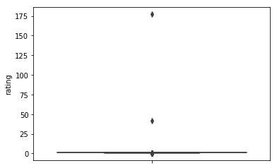

```python
# Boxplot of rating
sns.boxplot(y = 'rating', data = df)
plt.show()
```

```python
# See the 99.99 percentile value of rating:
np.percentile(df['rating'], 99.99)
```

```
149.49011999999564
```

```python
# Only consider rating without outliers:
df = df[df['rating'] < 1.5]
```

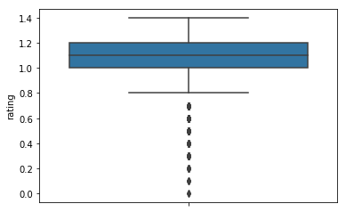

```python
# Boxplot of rating without outliers
sns.boxplot(y = 'rating', data = df)
plt.show()
```

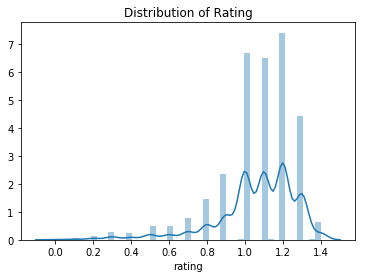

```python
sns.distplot(df['rating'])
plt.title('Distribution of Rating')
plt.show()
```

```python
# See percentile of rating of 1.0:
stats.percentileofscore(df['rating'], 1)
```

```
30.37180106228875
```

> 70% percentile of the dogs receiving rating more than 10 on the scale of 10. Because dogs are great!

```python
# Descriptive statistics of rating, retweets and favorites without outliers:
df[['rating', 'favorite_count', 'retweet_count']].describe()
```

|  | rating | favorite_count | retweet_count |
| --- | --- | --- | --- |
| count | 2071.000000 | 2065.000000 | 2065.000000 |
| mean | 1.060926 | 8515.753995 | 2865.934625 |
| std | 0.216458 | 12435.064053 | 4848.545216 |
| min | 0.000000 | 0.000000 | 13.000000 |
| 25% | 1.000000 | 1633.000000 | 612.000000 |
| 50% | 1.100000 | 3769.000000 | 1356.000000 |
| 75% | 1.200000 | 10737.000000 | 3335.000000 |
| max | 1.400000 | 143195.000000 | 77235.000000 |

##### Dog breeds

```python
# Total number of dog breeds that have been rated:
len(df['breed'].unique())
```

```
114
```

```python
# Most popular dog breeds:
top_breed = df['breed'].value_counts()[df['breed'].value_counts() >35]
print(top_breed)
```

```
golden_retriever      172
Labrador_retriever    113
Pembroke               96
Chihuahua              95
pug                    65
toy_poodle             52
chow                   51
Samoyed                46
Pomeranian             42
Name: breed, dtype: int64
```

> There are 113 breeds that have appeared in the Twitter page. And Golden retriever is the most popular breed rated by WeRateDogs, taking the spotlight for 172 times. It is followered by Labrador retriver, Pembroke, Chihuahua and Pug.

```python
top_breed_list = top_breed.index.tolist()
```

```python
top_breed_data = df[df['breed'].isin(top_breed_list)]
```

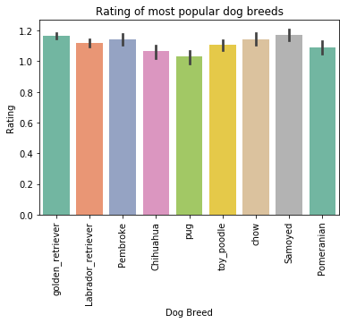

```python
sns.barplot(x = 'breed', y= 'rating', palette = 'Set2', estimator = np.mean, data = top_breed_data,  order = top_breed_data['breed'].value_counts().index)
plt.xticks(rotation='vertical')
plt.xlabel('Dog Breed')
plt.ylabel('Rating')
plt.title('Rating of most popular dog breeds')
plt.show()
```

> Golden Retriever is not only the most popular breed but also one of the most highly rated.

##### Retweets and Favorites overtime

```python
# Set index as timestamp so that
df.set_index('timestamp', inplace=True)
```

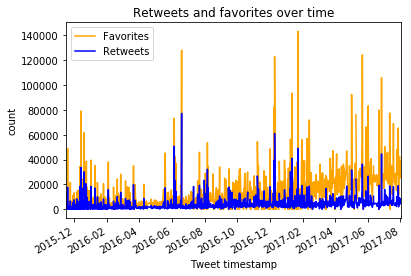

```python
df['favorite_count'].plot(color = 'orange', label='Favorites')
df['retweet_count'].plot(color = 'blue', label='Retweets')
plt.legend(loc='upper left')
plt.xlabel('Tweet timestamp')
plt.ylabel('count')
plt.title('Retweets and favorites over time')
plt.show()
```

It is shown from the above plot that the overall uptake of both favorites & retweets, with favourite increases more noticably than retweets. The page seems to be getting more popular, especially in terms of the number of favorites it receives. Another observation is the clear hype during January and July, holiday spirit seems to be around WeRateDogs these times!

##### Rating, Favourites and Retweets

```python
# Rounded rating to one decimal to create rating bins:
df['rating_rounded'] = df['rating'].apply(lambda x: np.round(x, decimals = 1))
```

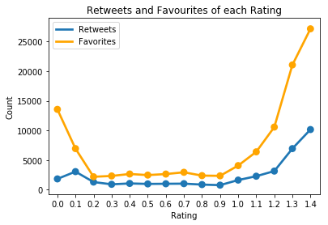

```python
sns.pointplot(x = 'rating_rounded', y = 'retweet_count', estimator = np.mean, data = df, ci = None, label = "Retweets")
sns.pointplot(x = 'rating_rounded', y = 'favorite_count', estimator = np.mean, data = df, ci = None, color= "orange", label = "Favorites")
plt.xlabel('Rating')
plt.ylabel('Count')
plt.title('Retweets and Favourites of each Rating')
plt.legend(['Retweets', 'Favorites'])
plt.show()
```

##### Dog Stage, Gender and Rating

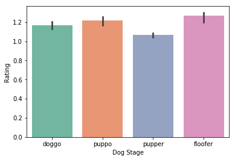

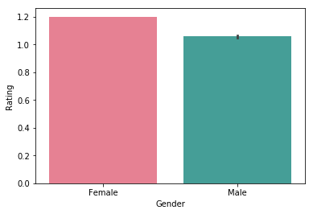

```python
sns.barplot(x = 'dog_stage', y = 'rating', data = df, estimator = np.mean, palette = 'Set2')
plt.xlabel('Dog Stage')
plt.ylabel('Rating')
plt.show()
sns.barplot(x = 'gender', y = 'rating', data = df, estimator = np.mean, palette = 'husl', order = ['Female', 'Male'])
plt.xlabel('Gender')
plt.ylabel('Rating')
plt.show()
```

##### Most popular dog names:

```python
dog_name = df['name'].value_counts()
```

```python
dog_name = dog_name.reset_index()
```

```python
dog_name.columns = ['words', 'count']
```

```python
print(dog_name)
```

```
         words  count
0      Charlie     11
1       Cooper     10
2       Tucker     10
3        Penny     10
4       Oliver     10
5         Lucy     10
6        Sadie      8
7      Winston      8
8           Bo      8
9         Lola      8
10        Toby      7
11       Daisy      7
12        Dave      6
13     Stanley      6
```

[output cut: 49 more lines]

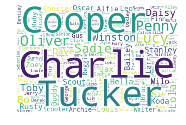

```python
# Create dog names word cloud.
d = {}
for a, x in dog_name.values:
    d[a] = x

import matplotlib.pyplot as plt

wordcloud = WordCloud(width = 600, height = 400, background_color = 'white')
wordcloud.generate_from_frequencies(frequencies=d)
plt.figure()
plt.imshow(wordcloud, interpolation="bilinear")
plt.axis("off")
plt.show()
```